# Chimp_Greying_Analysis1

Liz Tapanes

December 4, 2016

# Pan troglodytes (chimpanzee) hair greying

Is hair greying in Pan troglodytes a proper indicator of aging?

## Read in packages

```r
library(dplyr)
library(ggplot2)
library(pander)
```

## Read in File

```r
Chimps <- read.delim("Chimp_Greying_JustData_Rproj.txt", header = TRUE, sep = "\t")
pander(head(Chimps))
```

Table continues below

| Photo_number | Photo_ID | Sex | Age | Population | Face_Coloration_LizT |
| --- | --- | --- | --- | --- | --- |
| 1 | Kidman 2009 | F | 30 | Ngogo | 4 |
| 2 | Bartok 2009 | M | 32 | Ngogo | 4 |
| 3 | Cash 2005 | M | 12 | Ngogo | 1 |
| 4 | Corea 2005 | F | 21 | Ngogo | 2 |
| 5 | Dalton 2000 | M | 4 | NIRC | 1 |
| 6 | Brownface 2005 | M | 28 | Ngogo | 3 |

Table continues below

| Rater8 | Rater9 | Rater10 | Rater11 | Rater12 | Rater13 | Rater14 | Rtaer15 |
| --- | --- | --- | --- | --- | --- | --- | --- |
| 3 | 2 | 3 | 3 | 2 | 1 | 2 | 3 |
| 3 | 3 | 4 | 4 | 4 | 4 | 3 | 4 |
| 2 | 1 | 2 | 3 | 5 | 3 | 1 | 2 |
| 4 | 3 | 4 | 4 | 4 | 5 | 2 | 3 |
| 1 | 1 | 1 | 1 | 1 | 1 | 1 | 1 |
| 2 | 2 | 2 | 2 | 2 | 4 | 1 | 1 |

| Mean | Median | SD |
| --- | --- | --- |
| 2.375 | 2.5 | 0.696 |
| 3.625 | 4 | 0.4841 |
| 2.375 | 2 | 1.218 |
| 3.625 | 4 | 0.857 |
| 1 | 1 | 0 |
| 2 | 2 | 0.866 |

## Exploring the Dataframe

Explore data through summary and structure functions.

```r
summary(Chimps)
```

```
##   Photo_number        Photo_ID   Sex          Age       Population
##  Min.   :  1   Abe        :  1   F: 53   Min.   : 1.0   Ngogo:76
##  1st Qu.: 42   Abe2000    :  1   M:112   1st Qu.: 8.0   NIRC :42
##  Median : 83   Abrams 2009:  1           Median :15.0   TAI  :47
##  Mean   : 83   Alina3     :  1           Mean   :18.3
##  3rd Qu.:124   Amelia 2009:  1           3rd Qu.:29.0
##  Max.   :165   Aretha 2008:  1           Max.   :52.0
##                (Other)    :159
##  Face_Coloration_LizT     Rater8          Rater9         Rater10
##  Min.   :1.000        Min.   :1.000   Min.   :1.000   Min.   :1.000
##  1st Qu.:2.000        1st Qu.:1.000   1st Qu.:1.000   1st Qu.:1.000
##  Median :3.000        Median :2.000   Median :2.000   Median :3.000
##  Mean   :2.873        Mean   :2.358   Mean   :2.097   Mean   :2.715
##  3rd Qu.:4.000        3rd Qu.:4.000   3rd Qu.:3.000   3rd Qu.:4.000
##  Max.   :4.000        Max.   :5.000   Max.   :5.000   Max.   :5.000
##
##  Rater11    Rater12         Rater13         Rater14         Rtaer15
##  1:68    Min.   :1.000   Min.   :1.000   Min.   :1.000   Min.   :1.000
##  2:40    1st Qu.:1.000   1st Qu.:1.000   1st Qu.:1.000   1st Qu.:1.000
##  3:33    Median :2.000   Median :2.000   Median :2.000   Median :2.000
##  4:18    Mean   :2.012   Mean   :2.552   Mean   :2.442   Mean   :2.497
##  5: 5    3rd Qu.:3.000   3rd Qu.:4.000   3rd Qu.:3.000   3rd Qu.:4.000
##  b: 1    Max.   :5.000   Max.   :5.000   Max.   :5.000   Max.   :5.000
##
##       Mean           Median            SD
##  Min.   :1.000   Min.   :1.000   Min.   :0.0000
##  1st Qu.:1.250   1st Qu.:1.000   1st Qu.:0.4330
##  Median :2.250   Median :2.000   Median :0.5995
##  Mean   :2.347   Mean   :2.315   Mean   :0.5814
##  3rd Qu.:3.125   3rd Qu.:3.000   3rd Qu.:0.7806
##  Max.   :5.000   Max.   :5.000   Max.   :1.5518
##
```

```r
str(Chimps)
```

```
## 'data.frame':    165 obs. of  17 variables:
##  $ Photo_number        : int  1 2 3 4 5 6 7 8 9 10 ...
##  $ Photo_ID            : Factor w/ 165 levels "Abe ","Abe2000",..: 76 10 22 28 31 17 49 12 34 47 ...
##  $ Sex                 : Factor w/ 2 levels "F","M": 1 2 2 1 2 2 2 2 2 2 ...
##  $ Age                 : int  30 32 12 21 4 28 2 28 21 29 ...
##  $ Population          : Factor w/ 3 levels "Ngogo","NIRC",..: 1 1 1 1 2 1 1 1 1 1 ...
##  $ Face_Coloration_LizT: int  4 4 1 2 1 3 1 4 2 3 ...
##  $ Rater8              : int  3 3 2 4 1 2 1 5 2 1 ...
##  $ Rater9              : int  2 3 1 3 1 2 1 3 2 2 ...
##  $ Rater10             : int  3 4 2 4 1 2 1 5 4 4 ...
##  $ Rater11             : Factor w/ 6 levels "1","2","3","4",..: 3 4 3 4 1 2 1 5 3 4 ...
##  $ Rater12             : int  2 4 5 4 1 2 1 4 3 2 ...
##  $ Rater13             : int  1 4 3 5 1 4 1 4 4 2 ...
##  $ Rater14             : int  2 3 1 2 1 1 1 2 2 2 ...
##  $ Rtaer15             : int  3 4 2 3 1 1 1 4 3 4 ...
##  $ Mean                : num  2.38 3.62 2.38 3.62 1 ...
##  $ Median              : num  2.5 4 2 4 1 2 1 4 3 2 ...
##  $ SD                  : num  0.696 0.484 1.218 0.857 0 ...
```

Pull the standard deviation for variable of interest: age across the entire dataset (sample).

```r
AGEsd <- sd(Chimps$Age)
AGEsd
```

```
## [1] 12.88525
```

Pull the standard deviation for variable of interest: age, grouped by population.

```r
AGEPopSd <- Chimps %>% group_by(Population) %>% summarize(STdevChimpAge = sd(Age))
AGEPopSd
```

```
## # A tibble: 3 × 2
##   Population STdevChimpAge
##       <fctr>         <dbl>
## 1      Ngogo      11.62435
## 2       NIRC      13.84198
## 3        TAI      13.71961
```

Pull the standard deviation for variable of interest: age, grouped by sex.

```r
AGESexSd <- Chimps %>% group_by(Sex) %>% summarize(STdevChimpSex = sd(Age))
AGESexSd
```

```
## # A tibble: 2 × 2
##      Sex STdevChimpSex
##   <fctr>         <dbl>
## 1      F      14.22767
## 2      M      12.10899
```

## Dataframe Transformations

Change Rater 11 to an integer. Structure exploration showed it imported as a factor.

```r
Chimps$Rater11 <- as.integer(Chimps$Rater11)
```

### Create functions and add columns

Create a function to produce row medians. The arguements to the function call “x” and na.rm = FALSE to indicate to calculate function regardless of any “NA” values in the row. The function calls says to apply “x” over rows, and to produce a “median”, and na.rm is set to equal itself.

```r
rowMedian <- function(x, na.rm = FALSE)
    apply(x, 1, median, na.rm = na.rm)
```

Create a function to produce row standard deviations, in a similar fashion as above, except apply goes over rows using “sd” to produce a standard deviation.

```r
rowSD <- function(x, na.rm = FALSE)
  apply(x, 1, sd, na.rm = na.rm)
```

I add columns to the dataframe using the functions above + an already built in function for rowMeans. Here RaterMean = Average value of greying in each Chimpanzee photo. Accordingly, each new column is produced by calling the function and applying it to columns 7:14.

```r
Chimps$RaterMean <- rowMeans(Chimps[,7:14])
Chimps$RaterMedian <- rowMedian(Chimps[,7:14])
Chimps$RaterSD <- rowSD(Chimps[,7:14])

pander(head(Chimps))
```

Table continues below

| Photo_number | Photo_ID | Sex | Age | Population | Face_Coloration_LizT |
| --- | --- | --- | --- | --- | --- |
| 1 | Kidman 2009 | F | 30 | Ngogo | 4 |
| 2 | Bartok 2009 | M | 32 | Ngogo | 4 |
| 3 | Cash 2005 | M | 12 | Ngogo | 1 |
| 4 | Corea 2005 | F | 21 | Ngogo | 2 |
| 5 | Dalton 2000 | M | 4 | NIRC | 1 |
| 6 | Brownface 2005 | M | 28 | Ngogo | 3 |

Table continues below

| Rater8 | Rater9 | Rater10 | Rater11 | Rater12 | Rater13 | Rater14 | Rtaer15 |
| --- | --- | --- | --- | --- | --- | --- | --- |
| 3 | 2 | 3 | 3 | 2 | 1 | 2 | 3 |
| 3 | 3 | 4 | 4 | 4 | 4 | 3 | 4 |
| 2 | 1 | 2 | 3 | 5 | 3 | 1 | 2 |
| 4 | 3 | 4 | 4 | 4 | 5 | 2 | 3 |
| 1 | 1 | 1 | 1 | 1 | 1 | 1 | 1 |
| 2 | 2 | 2 | 2 | 2 | 4 | 1 | 1 |

| Mean | Median | SD | RaterMean | RaterMedian | RaterSD |
| --- | --- | --- | --- | --- | --- |
| 2.375 | 2.5 | 0.696 | 2.375 | 2.5 | 0.744 |
| 3.625 | 4 | 0.4841 | 3.625 | 4 | 0.5175 |
| 2.375 | 2 | 1.218 | 2.375 | 2 | 1.302 |
| 3.625 | 4 | 0.857 | 3.625 | 4 | 0.9161 |
| 1 | 1 | 0 | 1 | 1 | 0 |
| 2 | 2 | 0.866 | 2 | 2 | 0.9258 |

## Testing assumptions of normality

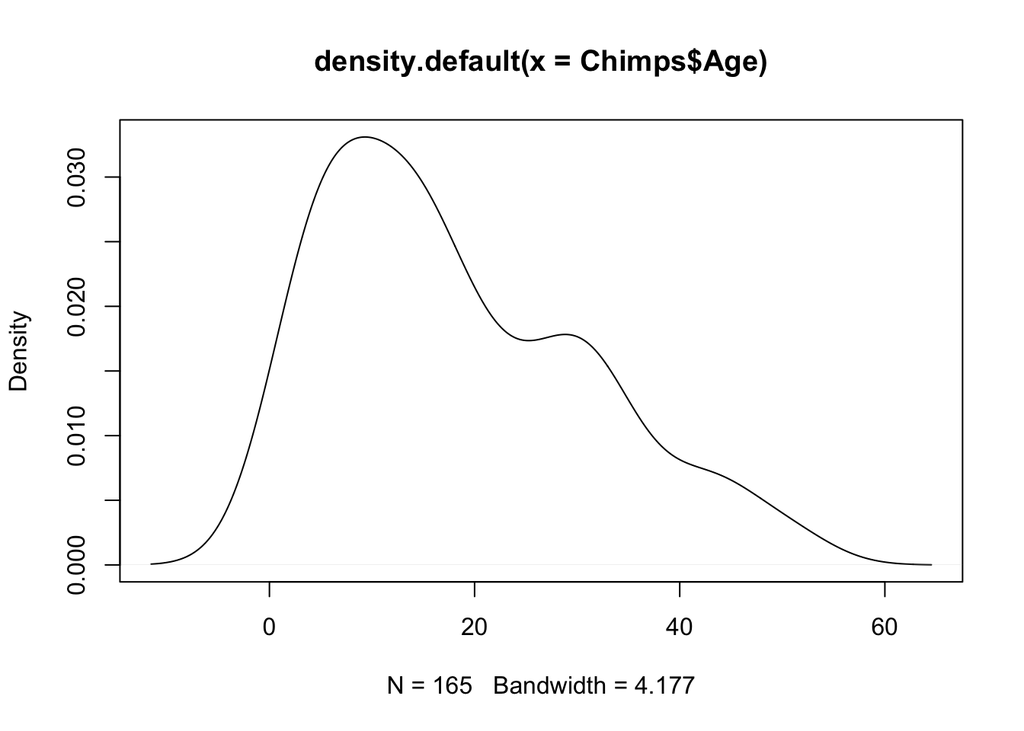

```r
plot(density(Chimps$Age))
```

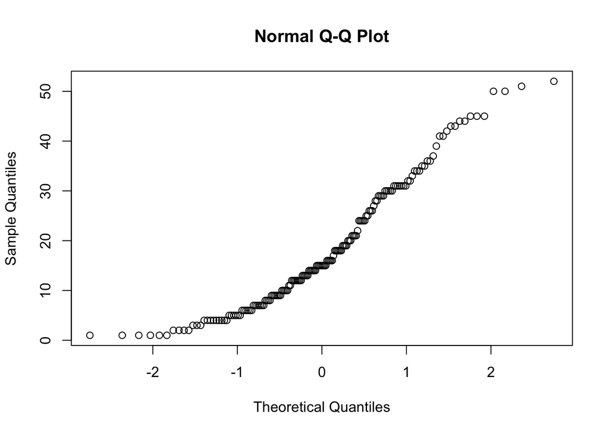

```r
qqnorm(Chimps$Age)
```

## Analyze the data + cooresponding visuals

### Does age coorelate with greying (main objective)?

I.e. Is hair greying in Pan troglodytes a proper indicator of aging?

```r
ChimpMod1 <- lm(RaterMean~Age, data = Chimps)
summary(ChimpMod1)
```

```
##
## Call:
## lm(formula = RaterMean ~ Age, data = Chimps)
##
## Residuals:
##     Min      1Q  Median      3Q     Max
## -2.2432 -0.4708 -0.2779  0.4345  2.7286
##
## Coefficients:
##             Estimate Std. Error t value Pr(>|t|)
## (Intercept)  1.22514    0.11113   11.02   <2e-16 ***
## Age          0.06142    0.00497   12.36   <2e-16 ***
## ---
## Signif. codes:  0 '***' 0.001 '**' 0.01 '*' 0.05 '.' 0.1 ' ' 1
##
## Residual standard error: 0.8201 on 163 degrees of freedom
## Multiple R-squared:  0.4837, Adjusted R-squared:  0.4805
## F-statistic: 152.7 on 1 and 163 DF,  p-value: < 2.2e-16
```

```r
anova(ChimpMod1)
```

```
## Analysis of Variance Table
##
## Response: RaterMean
##            Df Sum Sq Mean Sq F value    Pr(>F)
## Age         1 102.70 102.705  152.71 < 2.2e-16 ***
## Residuals 163 109.62   0.673
## ---
## Signif. codes:  0 '***' 0.001 '**' 0.01 '*' 0.05 '.' 0.1 ' ' 1
```

Result: I reject the null hypothesis that there is no relationship between greying and age.

Visual:

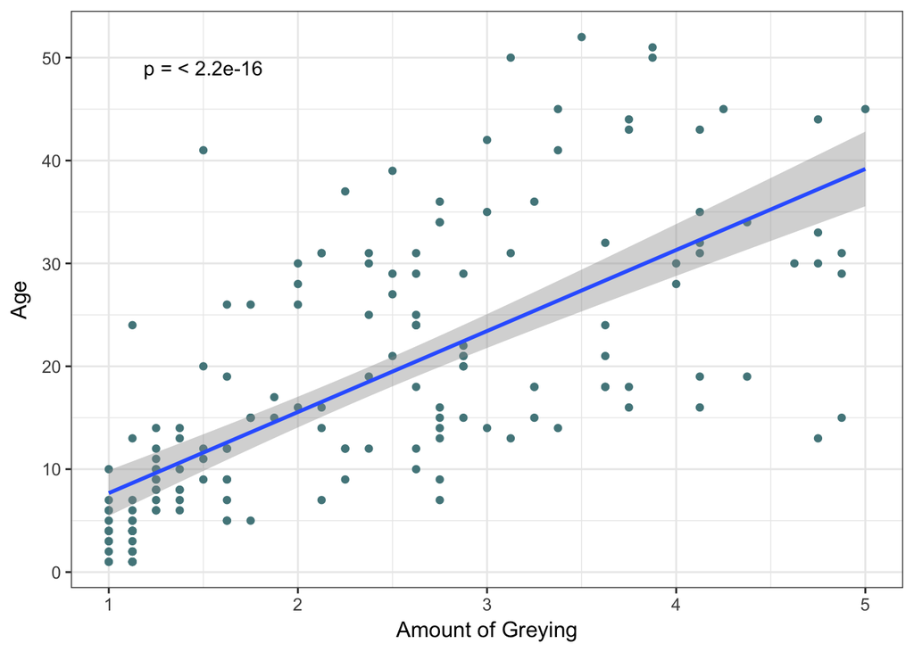

Greying Across Age for Pan troglodytes

```r
Mod1Plot <- ggplot(Chimps, aes(RaterMean, Age, color= Age)) + geom_point(col = "cadetblue4") + theme_bw(12) + stat_smooth(method = 'lm') + labs(x= "Amount of Greying") + annotate("text", x=1.5, y=49, label=paste("p = < 2.2e-16"))
Mod1Plot
```

### Does facial coloration correlate with the presence of grey hairs (sub-objective #1)?

```r
Chimps$Face_Coloration_LizT <- as.factor(Chimps$Face_Coloration_LizT)

ChimpMod2 <- lm(RaterMean~Face_Coloration_LizT, data = Chimps)
summary(ChimpMod2)
```

```
##
## Call:
## lm(formula = RaterMean ~ Face_Coloration_LizT, data = Chimps)
##
## Residuals:
##     Min      1Q  Median      3Q     Max
## -1.8729 -0.5102 -0.1352  0.5531  2.4898
##
## Coefficients:
##                       Estimate Std. Error t value Pr(>|t|)
## (Intercept)             1.2344     0.2309   5.345 3.05e-07 ***
## Face_Coloration_LizT2   0.4008     0.2660   1.507    0.134
## Face_Coloration_LizT3   1.4625     0.2732   5.352 2.94e-07 ***
## Face_Coloration_LizT4   1.7635     0.2599   6.785 2.10e-10 ***
## ---
## Signif. codes:  0 '***' 0.001 '**' 0.01 '*' 0.05 '.' 0.1 ' ' 1
##
## Residual standard error: 0.9237 on 161 degrees of freedom
## Multiple R-squared:  0.353,  Adjusted R-squared:  0.3409
## F-statistic: 29.28 on 3 and 161 DF,  p-value: 3.667e-15
```

```r
anova(ChimpMod2)
```

```
## Analysis of Variance Table
##
## Response: RaterMean
##                       Df Sum Sq Mean Sq F value    Pr(>F)
## Face_Coloration_LizT   3  74.95 24.9834  29.279 3.667e-15 ***
## Residuals            161 137.38  0.8533
## ---
## Signif. codes:  0 '***' 0.001 '**' 0.01 '*' 0.05 '.' 0.1 ' ' 1
```

Test: One-way ANOVA

Note: Transform face_coloration from continuous to factoral data.

Result: Reject the null hypothesis that darker face coloration does not coorelate with the presence of grey hairs. The probability of observed values (p-value) is extreme: 3.667e-15.

Visual:

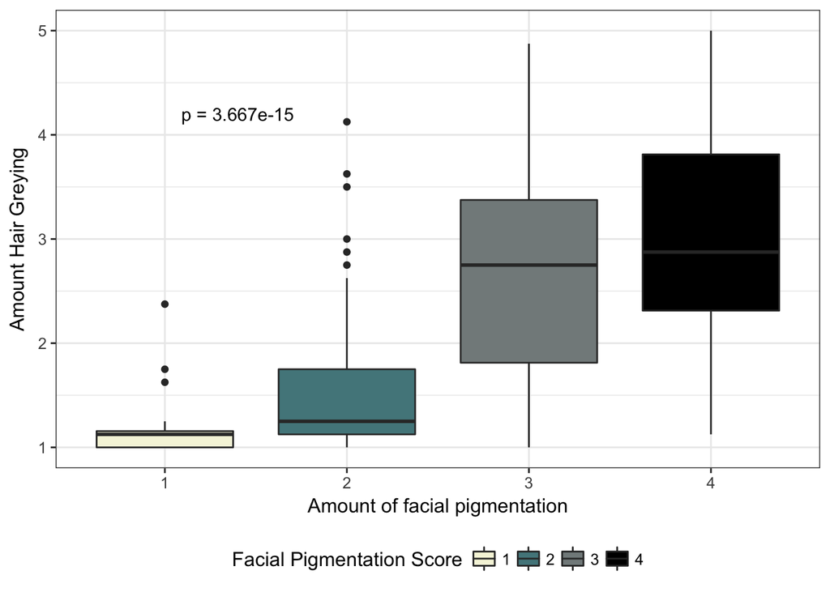

Facial Pigmentation and Hair Greying in Pan troglodytes

```r
Mod2Plot <- qplot(x= Face_Coloration_LizT, y= RaterMean, data=Chimps, geom="boxplot", fill=Face_Coloration_LizT) + theme_bw(12) + labs(y = "Amount Hair Greying", x = "Amount of facial pigmentation") + scale_fill_manual(values = c("beige", "cadetblue4", "azure4", "black"))  + guides(fill=guide_legend(title="Facial Pigmentation Score")) + theme(legend.position = "bottom") + annotate("text", x=1.4, y=4.2, label=paste("p = 3.667e-15"))
Mod2Plot
```

### Do males and females differ in the degree of hair greying exhibited (sub-objective #2)?

```r
t.test(RaterMean~Sex, data=subset(Chimps, Sex %in% c("F", "M")))
```

```
##
##  Welch Two Sample t-test
##
## data:  RaterMean by Sex
## t = 0.37389, df = 109.44, p-value = 0.7092
## alternative hypothesis: true difference in means is not equal to 0
## 95 percent confidence interval:
##  -0.2976822  0.4361172
## sample estimates:
## mean in group F mean in group M
##        2.396226        2.327009
```

Test: Unpaired T-test.

Result: Accept the Null hypothesis that males and females do not differ in degree of hair greying exhibited, probability of observed data (p-value) is 0.7092.

Visual:

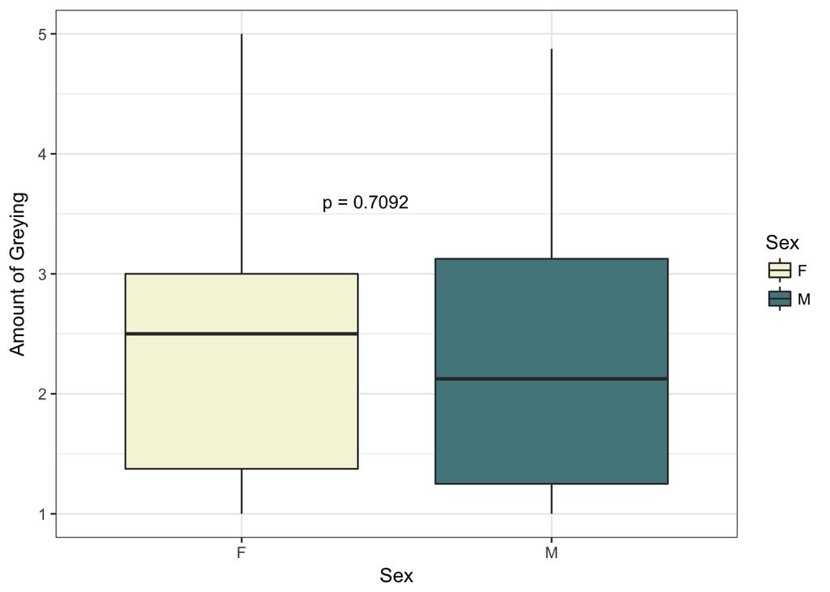

Greying variation in Male and Female Pan troglodytes

```r
AgePlot <- qplot(x= Sex, y= RaterMean, data=Chimps, geom="boxplot", fill=Sex) + theme_bw(12) + annotate("text", x=1.4, y=3.6, label=paste("p = 0.7092")) + labs(y = "Amount of Greying") + scale_fill_manual(values = c("beige", "cadetblue4"))
AgePlot
```

Visual (additional):

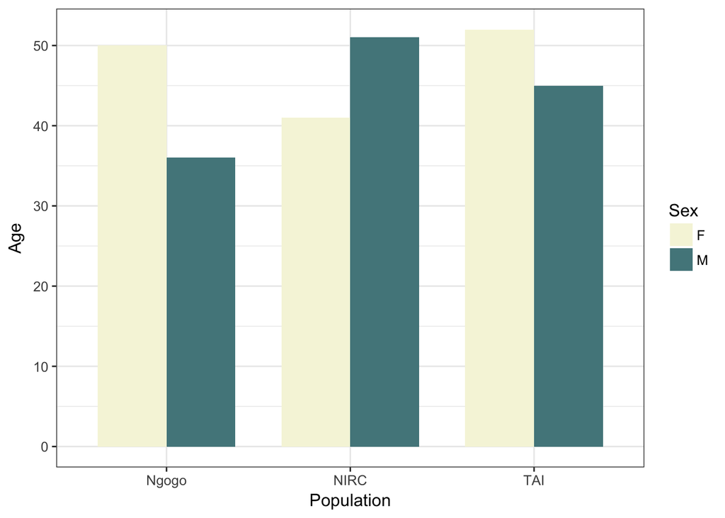

Distribution of Age Variation Across Populations of Pan troglodytes

```r
AgePopPlot <- ggplot(Chimps, aes(x= Population, y= Age)) + geom_bar(position = "dodge", width = 0.75, stat = "identity", aes(fill= Sex)) + scale_fill_manual(values = c("beige", "cadetblue4")) + theme_bw(12)
AgePopPlot
```

### Does greying differ for Tai, Ngogo, and NIRC chimpanzees (sub-objective #3)?

```r
ChimpMod3 <- lm(RaterMean~Population, data = Chimps)
summary(ChimpMod3)
```

```
##
## Call:
## lm(formula = RaterMean ~ Population, data = Chimps)
##
## Residuals:
##     Min      1Q  Median      3Q     Max
## -1.5658 -0.9202 -0.1702  0.7048  2.4375
##
## Coefficients:
##                Estimate Std. Error t value Pr(>|t|)
## (Intercept)      2.5658     0.1274  20.142  < 2e-16 ***
## PopulationNIRC  -0.1283     0.2135  -0.601  0.54879
## PopulationTAI   -0.6456     0.2061  -3.133  0.00206 **
## ---
## Signif. codes:  0 '***' 0.001 '**' 0.01 '*' 0.05 '.' 0.1 ' ' 1
##
## Residual standard error: 1.111 on 162 degrees of freedom
## Multiple R-squared:  0.05907,    Adjusted R-squared:  0.04745
## F-statistic: 5.085 on 2 and 162 DF,  p-value: 0.007214
```

```r
anova(ChimpMod3)
```

```
## Analysis of Variance Table
##
## Response: RaterMean
##             Df  Sum Sq Mean Sq F value   Pr(>F)
## Population   2  12.542  6.2711   5.085 0.007214 **
## Residuals  162 199.786  1.2332
## ---
## Signif. codes:  0 '***' 0.001 '**' 0.01 '*' 0.05 '.' 0.1 ' ' 1
```

Test: One-way ANOVA

Result: Reject the null hypothesis. There is a difference between populations on degree of greying.

Visual:

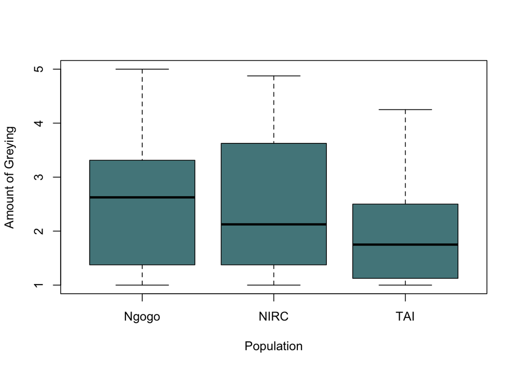

Hair Greying Across Populations of Pan troglodytes

```r
Mod3Plot <- boxplot(RaterMean~Population, data = Chimps, font.main=3, cex.main=1.2, xlab="Population", ylab="Amount of Greying", font.lab=3, col="cadetblue4")
```

```r
Mod3Plot
```

```
## $stats
##        [,1]  [,2]  [,3]
## [1,] 1.0000 1.000 1.000
## [2,] 1.3750 1.375 1.125
## [3,] 2.6250 2.125 1.750
## [4,] 3.3125 3.625 2.500
## [5,] 5.0000 4.875 4.250
##
## $n
## [1] 76 42 47
##
## $conf
##          [,1]     [,2]     [,3]
## [1,] 2.273851 1.576452 1.433108
## [2,] 2.976149 2.673548 2.066892
##
## $out
## numeric(0)
##
## $group
## numeric(0)
##
## $names
## [1] "Ngogo" "NIRC"  "TAI"
```

### Does greying differ with age for Pan in captivity vs in the wild (sub-objective #4)?

```r
PopType <- function(x) {
 if (x == "NIRC") print("captive")
  else print("wild")
}

Chimps$PopType <- sapply(Chimps$Population, PopType)
```

[output not shown]

[output cut: 150 more lines]

```r
pander(head(Chimps))
```

Table continues below

| Photo_number | Photo_ID | Sex | Age | Population | Face_Coloration_LizT |
| --- | --- | --- | --- | --- | --- |
| 1 | Kidman 2009 | F | 30 | Ngogo | 4 |
| 2 | Bartok 2009 | M | 32 | Ngogo | 4 |
| 3 | Cash 2005 | M | 12 | Ngogo | 1 |
| 4 | Corea 2005 | F | 21 | Ngogo | 2 |
| 5 | Dalton 2000 | M | 4 | NIRC | 1 |
| 6 | Brownface 2005 | M | 28 | Ngogo | 3 |

Table continues below

| Rater8 | Rater9 | Rater10 | Rater11 | Rater12 | Rater13 | Rater14 | Rtaer15 |
| --- | --- | --- | --- | --- | --- | --- | --- |
| 3 | 2 | 3 | 3 | 2 | 1 | 2 | 3 |
| 3 | 3 | 4 | 4 | 4 | 4 | 3 | 4 |
| 2 | 1 | 2 | 3 | 5 | 3 | 1 | 2 |
| 4 | 3 | 4 | 4 | 4 | 5 | 2 | 3 |
| 1 | 1 | 1 | 1 | 1 | 1 | 1 | 1 |
| 2 | 2 | 2 | 2 | 2 | 4 | 1 | 1 |

| Mean | Median | SD | RaterMean | RaterMedian | RaterSD | PopType |
| --- | --- | --- | --- | --- | --- | --- |
| 2.375 | 2.5 | 0.696 | 2.375 | 2.5 | 0.744 | wild |
| 3.625 | 4 | 0.4841 | 3.625 | 4 | 0.5175 | wild |
| 2.375 | 2 | 1.218 | 2.375 | 2 | 1.302 | wild |
| 3.625 | 4 | 0.857 | 3.625 | 4 | 0.9161 | wild |
| 1 | 1 | 0 | 1 | 1 | 0 | captive |
| 2 | 2 | 0.866 | 2 | 2 | 0.9258 | wild |

```r
ChimpMod4 <- lm(RaterMean~PopType+Age, data = Chimps)
summary(ChimpMod4)
```

```
##
## Call:
## lm(formula = RaterMean ~ PopType + Age, data = Chimps)
##
## Residuals:
##     Min      1Q  Median      3Q     Max
## -2.4812 -0.5081 -0.2585  0.4928  2.8058
##
## Coefficients:
##              Estimate Std. Error t value Pr(>|t|)
## (Intercept)  1.425165   0.148921   9.570   <2e-16 ***
## PopTypewild -0.291087   0.145885  -1.995   0.0477 *
## Age          0.062343   0.004947  12.603   <2e-16 ***
## ---
## Signif. codes:  0 '***' 0.001 '**' 0.01 '*' 0.05 '.' 0.1 ' ' 1
##
## Residual standard error: 0.8127 on 162 degrees of freedom
## Multiple R-squared:  0.4961, Adjusted R-squared:  0.4899
## F-statistic: 79.74 on 2 and 162 DF,  p-value: < 2.2e-16
```

```r
anova(ChimpMod4)
```

```
## Analysis of Variance Table
##
## Response: RaterMean
##            Df  Sum Sq Mean Sq  F value Pr(>F)
## PopType     1   0.439   0.439   0.6645 0.4162
## Age         1 104.896 104.896 158.8243 <2e-16 ***
## Residuals 162 106.993   0.660
## ---
## Signif. codes:  0 '***' 0.001 '**' 0.01 '*' 0.05 '.' 0.1 ' ' 1
```

Test: Two-way Anova

## Conclusion

Hair greying and age show a positive coorelation such that the p-value indicates the probability you observe the given data, given the null hypothesis, is very low.

Also: 1) Darker facial coloration does correlate with the presence of grey hairs; 2) male and female chimps do not differ in the amount of grey hairs exhibited; 3) greying differs significantly between populations, & 4) greying varies according to population type (captive vs. wild).